# Metaketa I - Chapter 11 - Replication

# Notes on replication script

- This .Rmd file produces all tables, and figures reported in Chapter 11 of *Information, Accountability, and Cumulative Learning: Lessons from Metaketa I* in the order in which they appear in the text.
- The code exports results to folders “tables” and “figures” in this file’s directory.
- Replication options include:
  - `prep`: if `TRUE`, generate data from raw files, if `FALSE`, loads cleaned data
  - `n_iter`: number of permutations of treatment assignment used in randomization inference analysis.
  - `load_iter_matrix`: if `FALSE`, generate `n_iter` columns of treatment assignment according to each study’s assignment strategy. If `TRUE`, load existing assignment matrix with 2,000 iterations of treatment assignment.
  - `ri_action`: treatment effects and *p*-values from randomization inference can be generated from scratch if set to `"generate"`, loaded from existing file if (`"load"`), or not returned (`"ignore"`) in results. Note that these estimations may take a few hours depending on the value of `n_iter`.
  - `run_bayes`: if `TRUE`, will run Monte Carlo simulations. `run_bayes <- FALSE` will skip the Bayesian analysis.
  - `load_specification_matrices <- FALSE` will estimate, from scratch, treatment effects under all combinations of specification choices. Likewise, `load_mde_data <- FALSE` will re-run the diagnostic process for the minimal detectable effect analysis. Setting these options to `FALSE` will take several hours to run on an average machine.
  - `full_m1`: if `FALSE` turns off imputing `0`s for vote choice for cases with where voter turnout is 0 in the cleaned data.
- For a full clean replication empty the folders `figures` and `tables` and subfolder `data/temp` and set options: `prep <- TRUE`, `ri_action <- "generate"`, `run_bayes <- TRUE`, `load_iter_matrix <- FALSE`, `load_specification_matrices <- FALSE`, `load_mde_data <- FALSE`.
- This code requires installation of Rstan (unless `run_bayes <- FALSE`). See installation instructions [here](https://github.com/stan-dev/rstan/wiki/RStan-Getting-Started).
- The package `xlsx` requires a 64 bit Java install on PCs; for more detail see https://java.com/en/download/win10.jsp.

```r
  prep <- TRUE
  n_iter <- 2000
  load_iter_matrix <- TRUE
  ri_action <- "load"
  run_bayes <- TRUE
  load_specification_matrices <- TRUE
  load_mde_data <- TRUE
  full_m1 <- TRUE
```

```r
if(prep){
  madat <- pool_studies(add_vars= c("nij", "Q_alt", "N_alt",
                                    "lc5.councillor.party.switch", "lc5.chair.party.switch", "lc5.councillor.redistricted2016"))
  if(full_m1){
    madat$m1[is.na(madat$m1) & madat$m3==0] <- 0
    #m3==0 in Burkina Faso means unlikely to vote or definitely not voting.
    madat$m1[madat$m1==1 & madat$m3==0 & madat$ctry == "bf"] <- 0
    madat_raw <- pool_studies(dir = "data/temp")
    madat$m1_against <- ifelse(madat_raw$m1==0 & madat$m3==1, 1, 0)
    madat$m1_against[is.na(madat$m1_against) & madat$m3==0 & madat$ctry != "bf"] <- 0
    madat$m1_against[madat$m1==1 & madat$m3==0 & madat$ctry == "bf"] <- 0
    madat$m1NA <- (is.na(madat$m1) & madat$m3 == 1)

  }
  save(madat, file = "data/temp/madat.Rda")
  write.csv(madat, "madat.csv")
}

load("data/temp/madat.Rda")

# Load previously generated permutation matrices
if(load_iter_matrix){
  load("data/temp/assign_iter.Rda")
}else{
  system.time(assign_iter <- assign_i(madat, n_iter))
  save(assign_iter, file = "data/temp/assign_iter.Rda")
}
  madat_iter <- cbind.data.frame(madat, assign_iter)
  rm(assign_iter)
  save(madat_iter, file = "data/temp/madat_iter.Rda")
```

# Figure 11.1: Treatment Effect of Information on Incumbent Vote Choice

```r
  cov <- "m14i+m17i+m18i+m20i+m21i+m22i+m24i+m26i+m27i"

  t1c1 <-  results(dat = madat_iter, ri_p = ri_action, sims = n_iter,
                  file_rite_obj = "data/temp/ri_m1pool_all_g_unadj.Rda",
                  good = TRUE, depvar = "m1", exclude_councilors = FALSE)
  t1c2 <- results(dat = madat_iter, ri_p = ri_action, sims = n_iter,
                  file_rite_obj = "data/temp/ri_m1pool_ben_g_unadj.Rda",
                  depvar = "m1", weights = FALSE, good = TRUE, country = "ben")
  t1c3 <- results(dat = madat_iter, ri_p = ri_action, sims = n_iter,
                  file_rite_obj = "data/temp/ri_m1pool_brz_g_unadj.Rda",
                  depvar = "m1", weights = TRUE,  good = TRUE, country = "brz")
  t1c4 <- results(dat = madat_iter, ri_p = ri_action, sims = n_iter,
                  file_rite_obj = "data/temp/ri_m1pool_bf_g_unadj.Rda",
                  depvar = "m1", weights = FALSE, good = TRUE, country = "bf")
  t1c5 <- results(dat = madat_iter, ri_p = ri_action, sims = n_iter,
                  file_rite_obj = "data/temp/ri_m1pool_mex_g_unadj.Rda",
                  depvar = "m1", weights = FALSE, good = TRUE, country = "mex")
  t1c6 <- results(dat = madat_iter, ri_p = ri_action, sims = n_iter,
                  file_rite_obj = "data/temp/ri_m1pool_ug1_g_unadj.Rda",
                  depvar = "m1", weights = FALSE, good = TRUE, country = "ug1")
  t1c7 <- results(dat = madat_iter, ri_p = ri_action, sims = n_iter,
                  file_rite_obj = "data/temp/ri_m1pool_ug2_g_unadj.Rda",
                  depvar = "m1", weights = TRUE,  good = TRUE, country = "ug2",
                  exclude_councilors =FALSE)

   t2c1 <-  results(dat = madat_iter, ri_p = ri_action, sims = n_iter,
                  file_rite_obj = "data/temp/ri_m1pool_all_b_unadj.Rda",
                  good = FALSE, depvar = "m1", exclude_councilors =FALSE)
  t2c2 <- results(dat = madat_iter, ri_p = ri_action, sims = n_iter,
                  file_rite_obj = "data/temp/ri_m1pool_ben_b_unadj.Rda",
                  depvar = "m1", weights = FALSE, good = FALSE, country = "ben")
  t2c3 <- results(dat = madat_iter, ri_p = ri_action, sims = n_iter,
                  file_rite_obj = "data/temp/ri_m1pool_brz_b_unadj.Rda",
                  depvar = "m1", weights = TRUE,  good = FALSE, country = "brz")
  t2c4 <- results(dat = madat_iter, ri_p = ri_action, sims = n_iter,
                  file_rite_obj = "data/temp/ri_m1pool_bf_b_unadj.Rda",
                  depvar = "m1", weights = FALSE, good = FALSE, country = "bf")
  t2c5 <- results(dat = madat_iter, ri_p = ri_action, sims = n_iter,
                  file_rite_obj = "data/temp/ri_m1pool_mex_b_unadj.Rda",
                  depvar = "m1", weights = FALSE, good = FALSE, country = "mex")
  t2c6 <- results(dat = madat_iter, ri_p = ri_action, sims = n_iter,
                  file_rite_obj = "data/temp/ri_m1pool_ug1_b_unadj.Rda",
                  depvar = "m1", weights = FALSE, good = FALSE, country = "ug1")
  t2c7 <- results(dat = madat_iter, ri_p = ri_action, sims = n_iter,
                  file_rite_obj = "data/temp/ri_m1pool_ug2_b_unadj.Rda",
                  depvar = "m1", weights = TRUE,  good = FALSE, country = "ug2",
                  exclude_councilors =FALSE)
```

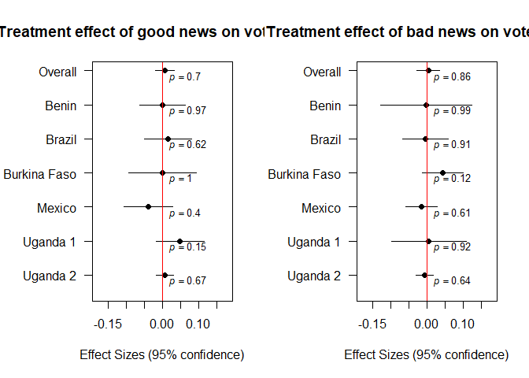

Meta-Analysis: Country-Specific Effects on Vote Choice. Estimated change in the proportion of voters who support an incumbent after receiving good news (left panel) or bad news (right panel) about the politician, compared to receiving no information. Weighted unadjusted estimates. Horizontal lines show 95% confidence intervals for the estimated change. Entries under each estimate show p-values calculated by randomization inference. In all cases, the differences are close to zero and statistically insignificant.